# Desafio de Varejo

Paulo A Cressoni

October 24, 2017

## Previsão de Vendas

Para prever venda dos produtos nos meses de junho, julho e agosto, vamos utilizar séries temporais.

Abaixo podemos notar que não há dados faltando no nosso *dataset*:

```
##         order_id             code         quantity            price
##                0                0                0                0
##       pis_cofins             icms tax_substitution         category
##                0                0                0                0
##      liquid_cost     order_status     capture_date     process_date
##                0                0                0                0
##   process_status   source_channel
##                0                0
```

Vamos utilizar o código de produto *2e35421c34fb588ba40a0c57b3971d24* para realizar um teste e verificar se a análise é válida.

Abaixo podemos ver o gráfico da quantidade de produtos por mês:

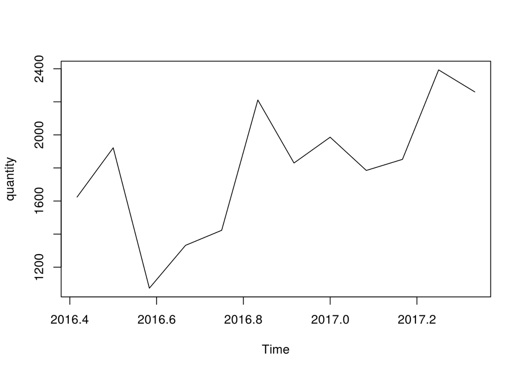

Podemos averiguar que as séries temporais criadas a partir do *dataset* disponível **nâo** é suficiente para completar o mínimo de **dois ciclos de dados** (neste caso dois anos completos). O que nos impede de poder retirar dados importantes, como a sazonalidade e *trend*, mas iremos continuar a análise temporal ignorando esses dados por enquanto.

Abaixo podemos ver no gráfico uma linha colorida que representa a curva mais suave que segue os valores desta série temporal:

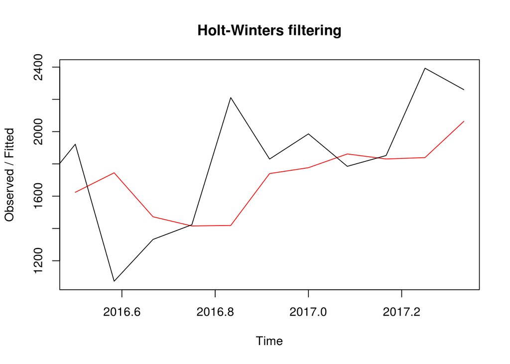

Abaixo temos o gráfico que representa a previsão dos três próximos mêses, e é composto do valor médio e os intervalos de valores altos e baixos de confiança de 80% e 95%:

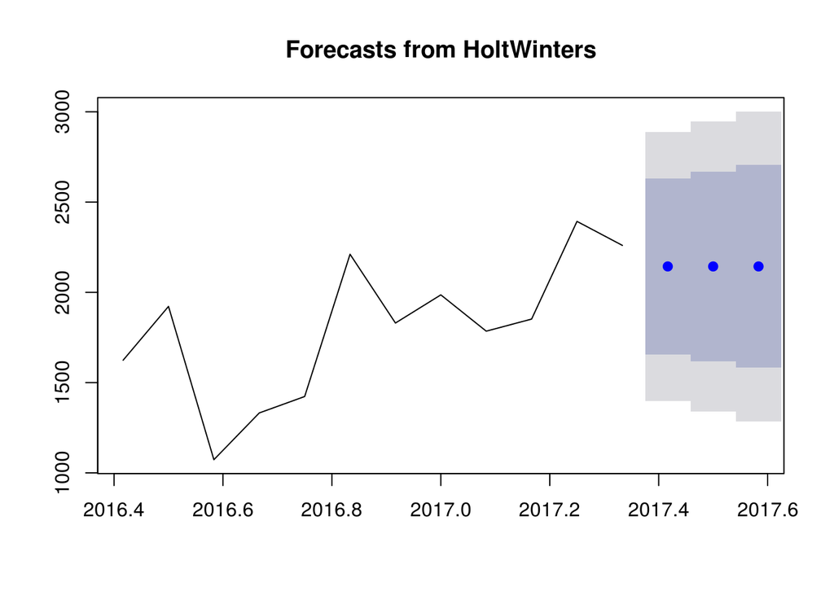

Abaixo temos um gráfico da quantidade de ruído (ou erro) presente nesta série temporal. Quanto mais distante do valor 0 no eixo *y*, maior o ruído. O ruído é a diferença entre o dado real da série e o novo dado gerado:

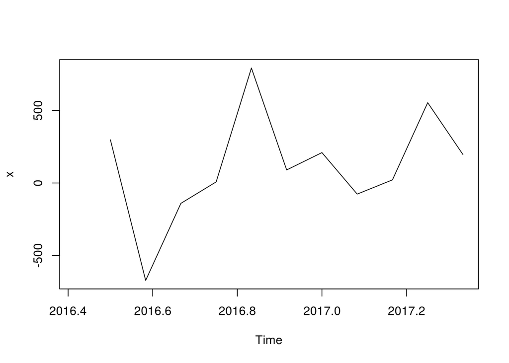

Abaixo temos uma outra representação gráfica do ruído, mas agora por histograma. Quanto maior a concentração no valor 0 do eixo *x*, menor o ruído.

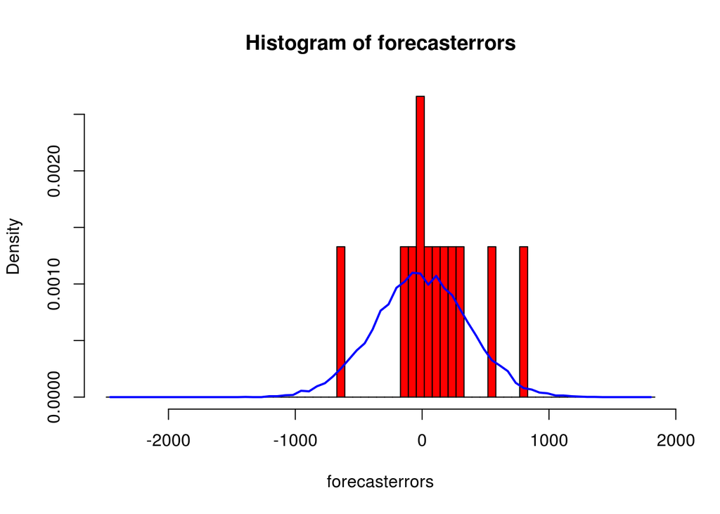

Abaixo podemos observar alguns dados de previsão dos três próximos mêses como a média, os valores baixos com intervalo de confiança de 80% e 95%, e os valores altos com intervalo de confiança de 80% e 95%:

```
##          Point Forecast    Lo 80    Hi 80    Lo 95    Hi 95
## Jun 2017        2143.46 1656.718 2630.201 1399.053 2887.866
## Jul 2017        2143.46 1618.182 2668.738 1340.116 2946.803
## Aug 2017        2143.46 1582.285 2704.634 1285.217 3001.702
```

A quantidade média necessária para cada produto nos mêses de junho, julho e agosto estão listados abaixo:

```
##                                 Prod  Jun  Jul  Ago
## 2   0671c2b9132a3f5215a4212ce0691694   14   14   14
## 3   09f544ec2a74c89abeec7b0590fc2d11   28   28   28
## 4   0ad316f6b5cb5e81ebff73ae2490ccfe    3    3    3
## 5   0bbe09e34a11e8e31cf49d6f8df2992d   34   34   34
## 6   0dca7ec6ba9b6e8f17f04f713a6be727   65   65   65
## 7   0f38be2df6854b4374f06cae1bc38482   39   39   39
## 8   118484c270085e811fbbc81978a269b2    0    0    0
## 9   13b69fd4bf80b95756e3b138c9169a7f   63   63   63
## 10  174ef25d9556d516a813e2972f3b8351  136  136  136
## 11  193628b6634713730d3c506f2da0ff58  539  539  539
## 12  1a225367d52023424b6f4b2aa8632615    1    1    1
## 13  1b3980ee40dc5d60ecae3b19cd41f49a   78   78   78
## 14  1c234775cae774823f38abe6721e61a4   51   51   51
## 15  1c619f92929dbaa41df54608dc70a7ce    3    3    3
```

[output cut: 117 more lines]

## Considerações Finais

Esta análise foi desenvolvida com o objetivo de informar a demanda de compra de cada produto listado acima, da melhor maneira possível de acordo com os dados que foram fornecidos. A análise pode ser muito mais apurada e os resultados optimizados caso haja um dataset mais extenso e completo.